# PGP in AIML Business Applciations

# Batch : PGP-AIML-BA-UTA-Sept20-C

# Name : Malleswara Rao Polimera

**Data Description**</br> A sentiment analysis job about the problems of each major U.S. airline. Twitter data was scraped from February of 2015 and contributors were asked to first classify positive, negative, and neutral tweets, followed by categorizing negative reasons (such as "late flight" or "rude service").

**Dataset:**</br> The project is from a dataset from Kaggle. Link to the Kaggle project site: https://www.kaggle.com/crowdflower/twitter-airline-sentiment </br> The dataset has the following columns:

- tweet_id
- airline_sentiment
- airline_sentiment_confidence
- negativereason
- negativereason_confidence
- airline
- airline_sentiment_gold
- name

## **Objective:**

To implement the techniques learnt as a part of the course.

## **Learning Outcomes:**

- Basic understanding of text pre-processing.
- What to do after text pre-processing: Bag of words / Tf-idf
- Build the classification model.
- Evaluate the Model.

# **1. Import the libraries, load dataset, print shape of data, data description. (5 Marks)**

```python
!pip install contractions
```

```python
# install and import necessary libraries.


import re, string, unicodedata                          # Import Regex, string and unicodedata.
import contractions                                     # Import contractions library.
from bs4 import BeautifulSoup                           # Import BeautifulSoup.

import numpy as np                                      # Import numpy.
import pandas as pd                                     # Import pandas.

import seaborn as sns
import matplotlib.pyplot as plt                         # To enable plotting graphs in Jupyter notebook
%matplotlib inline


import nltk                                             # Import Natural Language Tool-Kit.

nltk.download('stopwords')                              # Download Stopwords.
nltk.download('punkt')
nltk.download('wordnet')

from nltk.corpus import stopwords                       # Import stopwords.
from nltk.tokenize import word_tokenize, sent_tokenize  # Import Tokenizer.
from nltk.stem.wordnet import WordNetLemmatizer         # Import Lemmatizer.


from sklearn.ensemble import RandomForestClassifier
from sklearn.model_selection import cross_val_score
from sklearn.metrics import confusion_matrix,accuracy_score,precision_score,recall_score,f1_score,roc_auc_score
```

**Mount the drive**

```python
from google.colab import drive
drive.mount('/content/drive/')
```

```python
df = pd.read_csv('/content/drive/MyDrive/Colab_Notebooks/NLP/Tweets.csv')
df_original = df.copy()
```

```python
df.head()
```

|  | tweet_id | airline_sentiment | airline_sentiment_confidence | negativereason | negativereason_confidence | airline | airline_sentiment_gold | name | negativereason_gold | retweet_count | text | tweet_coord | tweet_created | tweet_location | user_timezone |
| --- | --- | --- | --- | --- | --- | --- | --- | --- | --- | --- | --- | --- | --- | --- | --- |
| 0 | 570306133677760513 | neutral | 1.0000 | NaN | NaN | Virgin America | NaN | cairdin | NaN | 0 | @VirginAmerica What @dhepburn said. | NaN | 2015-02-24 11:35:52 -0800 | NaN | Eastern Time (US & Canada) |
| 1 | 570301130888122368 | positive | 0.3486 | NaN | 0.0000 | Virgin America | NaN | jnardino | NaN | 0 | @VirginAmerica plus you've added commercials t... | NaN | 2015-02-24 11:15:59 -0800 | NaN | Pacific Time (US & Canada) |
| 2 | 570301083672813571 | neutral | 0.6837 | NaN | NaN | Virgin America | NaN | yvonnalynn | NaN | 0 | @VirginAmerica I didn't today... Must mean I n... | NaN | 2015-02-24 11:15:48 -0800 | Lets Play | Central Time (US & Canada) |
| 3 | 570301031407624196 | negative | 1.0000 | Bad Flight | 0.7033 | Virgin America | NaN | jnardino | NaN | 0 | @VirginAmerica it's really aggressive to blast... | NaN | 2015-02-24 11:15:36 -0800 | NaN | Pacific Time (US & Canada) |
| 4 | 570300817074462722 | negative | 1.0000 | Can't Tell | 1.0000 | Virgin America | NaN | jnardino | NaN | 0 | @VirginAmerica and it's a really big bad thing... | NaN | 2015-02-24 11:14:45 -0800 | NaN | Pacific Time (US & Canada) |

```python
print('Shape of the data frame:',df.shape)
```

```
Shape of the data frame: (14640, 15)
```

**OBSERVATIONS: Number of features in the initial data frame 15 and number of Tweets are 14640**

```python
df.info()
```

```
<class 'pandas.core.frame.DataFrame'>
RangeIndex: 14640 entries, 0 to 14639
Data columns (total 15 columns):
 #   Column                        Non-Null Count  Dtype
---  ------                        --------------  -----
 0   tweet_id                      14640 non-null  int64
 1   airline_sentiment             14640 non-null  object
 2   airline_sentiment_confidence  14640 non-null  float64
 3   negativereason                9178 non-null   object
 4   negativereason_confidence     10522 non-null  float64
 5   airline                       14640 non-null  object
 6   airline_sentiment_gold        40 non-null     object
 7   name                          14640 non-null  object
 8   negativereason_gold           32 non-null     object
 9   retweet_count                 14640 non-null  int64
 10  text                          14640 non-null  object
 11  tweet_coord                   1019 non-null   object
 12  tweet_created                 14640 non-null  object
 13  tweet_location                9907 non-null   object
 14  user_timezone                 9820 non-null   object
dtypes: float64(2), int64(2), object(11)
memory usage: 1.7+ MB
```

**OBSERVATIONS: Some of the features are having missing values as per above**

```python
df.describe()
```

|  | tweet_id | airline_sentiment_confidence | negativereason_confidence | retweet_count |
| --- | --- | --- | --- | --- |
| count | 1.464000e+04 | 14640.000000 | 10522.000000 | 14640.000000 |
| mean | 5.692184e+17 | 0.900169 | 0.638298 | 0.082650 |
| std | 7.791112e+14 | 0.162830 | 0.330440 | 0.745778 |
| min | 5.675883e+17 | 0.335000 | 0.000000 | 0.000000 |
| 25% | 5.685592e+17 | 0.692300 | 0.360600 | 0.000000 |
| 50% | 5.694779e+17 | 1.000000 | 0.670600 | 0.000000 |
| 75% | 5.698905e+17 | 1.000000 | 1.000000 | 0.000000 |
| max | 5.703106e+17 | 1.000000 | 1.000000 | 44.000000 |

**OBSERVATIONS:**

```python
# our point of interest is on Tweets and different sentiments under the Tweets
df['airline_sentiment'].describe()
```

```
count        14640
unique           3
top       negative
freq          9178
Name: airline_sentiment, dtype: object
```

**OBSERVATIONS: No missing records - count is same as observations or Tweets and More negitive sentiment Tweets as per data frame**

```python
# see value count of each sentiment
print('Unique values of the sentiments:',df['airline_sentiment'].unique())
print('Value Counts of each sentiment:\n',df['airline_sentiment'].value_counts())
```

```
Unique values of the sentiments: ['neutral' 'positive' 'negative']
Value Counts of each sentiment:
 negative    9178
neutral     3099
positive    2363
Name: airline_sentiment, dtype: int64
```

```python
df['airline_sentiment'].value_counts(normalize=True)
```

```
negative    0.626913
neutral     0.211680
positive    0.161407
Name: airline_sentiment, dtype: float64
```

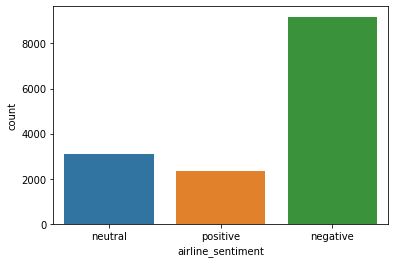

```python
sns.countplot(x='airline_sentiment',data=df)
plt.show()
```

**OBSERVATIONS:**

- **airline_sentiment feature dont have any missing values**
- **Three unique sentiments are identified from the dataset**
- **top one is negative setiment and frequency is 9178 (62%)**
- **This data set is inbalanced**

```python
df['text'].describe()
```

```
count              14640
unique             14427
top       @united thanks
freq                   6
Name: text, dtype: object
```

```python
df['text'].isna().sum().sum()
```

```
0
```

**OBSERVATIONS: No Missing Tweets in the text feature**

```python
df_original['airline'].unique()
```

```
array(['Virgin America', 'United', 'Southwest', 'Delta', 'US Airways',
       'American'], dtype=object)
```

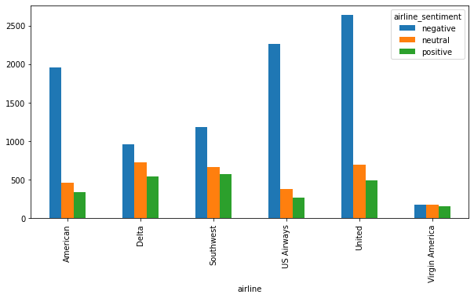

```python
%matplotlib inline
pd.crosstab(df_original['airline'],df_original['airline_sentiment']).plot(kind='bar',figsize=(10,5))
```

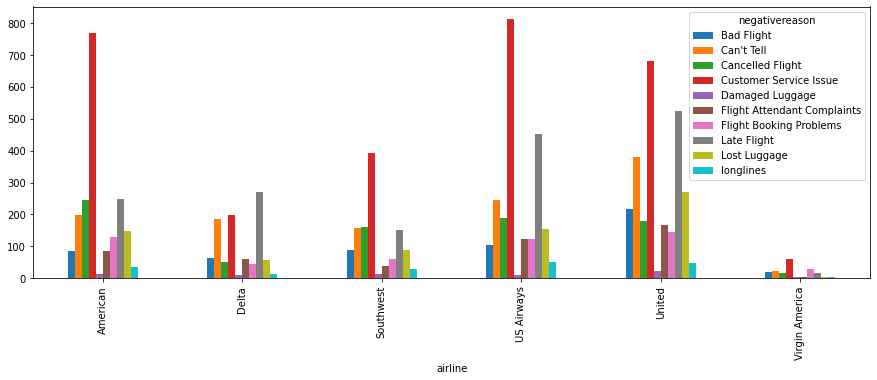

```python
pd.crosstab(df_original['airline'],df_original['negativereason']).plot(kind='bar',figsize=(15,5))
```

**OBSERVATIONS: Most of the negative reason is customer service Issues**

# **2. Understand of data-columns: (5 Marks)**

- **a. Drop all other columns except “text” and “airline_sentiment”.**
- **b. Check the shape of data.**
- **c. Print first 5 rows of data.**

```python
df.columns
```

```
Index(['tweet_id', 'airline_sentiment', 'airline_sentiment_confidence',
       'negativereason', 'negativereason_confidence', 'airline',
       'airline_sentiment_gold', 'name', 'negativereason_gold',
       'retweet_count', 'text', 'tweet_coord', 'tweet_created',
       'tweet_location', 'user_timezone'],
      dtype='object')
```

```python
# Drop all other columns except “text” and “airline_sentiment”.
df_t = df.drop(columns=['tweet_id','airline_sentiment_confidence','negativereason',
                        'negativereason_confidence', 'airline','airline_sentiment_gold', 'name', 'negativereason_gold',
                        'retweet_count','tweet_coord', 'tweet_created', 'tweet_location', 'user_timezone'],axis=1)
```

```python
# Check the shape of data.
print('Shape of the data: ', df_t.shape)
```

```
Shape of the data:  (14640, 2)
```

```python
# Print first 5 rows of data.
df_t.head()
```

|  | airline_sentiment | text |
| --- | --- | --- |
| 0 | neutral | @VirginAmerica What @dhepburn said. |
| 1 | positive | @VirginAmerica plus you've added commercials t... |
| 2 | neutral | @VirginAmerica I didn't today... Must mean I n... |
| 3 | negative | @VirginAmerica it's really aggressive to blast... |
| 4 | negative | @VirginAmerica and it's a really big bad thing... |

```python
pd.set_option('display.max_colwidth', None)
df_t.head()
```

|  | airline_sentiment | text |
| --- | --- | --- |
| 0 | neutral | @VirginAmerica What @dhepburn said. |
| 1 | positive | @VirginAmerica plus you've added commercials to the experience... tacky. |
| 2 | neutral | @VirginAmerica I didn't today... Must mean I need to take another trip! |
| 3 | negative | @VirginAmerica it's really aggressive to blast obnoxious "entertainment" in your guests' faces &amp; they have little recourse |
| 4 | negative | @VirginAmerica and it's a really big bad thing about it |

# **3. Text pre-processing: Data preparation. (20 Marks)**</br>

- **a. Html tag removal.**
- **b. Tokenization.**
- **c. Remove the numbers.**
- **d. Removal of Special Characters and Punctuations.**
- **e. Conversion to lowercase.**
- **f. Lemmatize or stemming.**
- **g. Join the words in the list to convert back to text string in the dataframe. (So that each row contains the data in text format.)**
- **h. Print first 5 rows of data after pre-processing.**

```python
# Html tag removal.
def strip_html(text):
  soup = BeautifulSoup(text,"html.parser")
  return soup.get_text()

df_t['text'] = df_t['text'].apply(lambda x: strip_html(x))
df_t.head()
```

|  | airline_sentiment | text |
| --- | --- | --- |
| 0 | neutral | @VirginAmerica What @dhepburn said. |
| 1 | positive | @VirginAmerica plus you've added commercials to the experience... tacky. |
| 2 | neutral | @VirginAmerica I didn't today... Must mean I need to take another trip! |
| 3 | negative | @VirginAmerica it's really aggressive to blast obnoxious "entertainment" in your guests' faces & they have little recourse |
| 4 | negative | @VirginAmerica and it's a really big bad thing about it |

```python
# Remove Contractions (e.g. replace I'm --> I am) and so on.\
def remove_contractions(text):
  return contractions.fix(text)

df_t['text'] = df_t['text'].apply(lambda x: remove_contractions(x))
df_t.head()
```

|  | airline_sentiment | text |
| --- | --- | --- |
| 0 | neutral | @VirginAmerica What @dhepburn said. |
| 1 | positive | @VirginAmerica plus you have added commercials to the experience... tacky. |
| 2 | neutral | @VirginAmerica I did not today... Must mean I need to take another trip! |
| 3 | negative | @VirginAmerica it is really aggressive to blast obnoxious "entertainment" in your guests' faces & they have little recourse |
| 4 | negative | @VirginAmerica and it is a really big bad thing about it |

```python
# remove numbers
def remove_numbers(text):
  text = re.sub(r'\d+', '', text)
  return text

df_t['text'] = df_t['text'].apply(lambda x: remove_numbers(x))
df_t.head()
```

|  | airline_sentiment | text |
| --- | --- | --- |
| 0 | neutral | @VirginAmerica What @dhepburn said. |
| 1 | positive | @VirginAmerica plus you have added commercials to the experience... tacky. |
| 2 | neutral | @VirginAmerica I did not today... Must mean I need to take another trip! |
| 3 | negative | @VirginAmerica it is really aggressive to blast obnoxious "entertainment" in your guests' faces & they have little recourse |
| 4 | negative | @VirginAmerica and it is a really big bad thing about it |

```python
# Tokenization
df_t['text'] = df_t.apply(lambda x: nltk.word_tokenize(x['text']), axis=1)
df_t.head()
```

|  | airline_sentiment | text |
| --- | --- | --- |
| 0 | neutral | [@, VirginAmerica, What, @, dhepburn, said, .] |
| 1 | positive | [@, VirginAmerica, plus, you, have, added, commercials, to, the, experience, ..., tacky, .] |
| 2 | neutral | [@, VirginAmerica, I, did, not, today, ..., Must, mean, I, need, to, take, another, trip, !] |
| 3 | negative | [@, VirginAmerica, it, is, really, aggressive, to, blast, obnoxious, ``, entertainment, '', in, your, guests, ', faces, &, they, have, little, recourse] |
| 4 | negative | [@, VirginAmerica, and, it, is, a, really, big, bad, thing, about, it] |

```python
# normalize the text with
def remove_non_ascii(words):
    """Remove non-ASCII characters from list of tokenized words"""
    new_words = []                        # Create empty list to store pre-processed words.
    for word in words:
        new_word = unicodedata.normalize('NFKD', word).encode('ascii', 'ignore').decode('utf-8', 'ignore')
        new_words.append(new_word)        # Append processed words to new list.
    return new_words

def to_lowercase(words):
    """Convert all characters to lowercase from list of tokenized words"""
    new_words = []                        # Create empty list to store pre-processed words.
    for word in words:
        new_word = word.lower()           # Converting to lowercase
        new_words.append(new_word)        # Append processed words to new list.
    return new_words

def remove_punctuation(words):
    """Remove punctuation from list of tokenized words"""
    new_words = []                        # Create empty list to store pre-processed words.
    for word in words:
        new_word = re.sub(r'[^\w\s]', '', word)
        if new_word != '':
            new_words.append(new_word)    # Append processed words to new list.
    return new_words

def remove_stopwords(words):
    """Remove stop words from list of tokenized words"""
    new_words = []                        # Create empty list to store pre-processed words.
    for word in words:
        if word not in stopwords.words('english'):
            new_words.append(word)        # Append processed words to new list.
    return new_words

def stem_words(words):
    """Stem words in list of tokenized words"""
    stemmer = LancasterStemmer()
    stems = []                            # Create empty list to store pre-processed words.
    for word in words:
        stem = stemmer.stem(word)
        stems.append(stem)                # Append processed words to new list.
    return stems

def lemmatize_verbs(words):
    """Lemmatize verbs in list of tokenized words"""
    lemmatizer = WordNetLemmatizer()
    lemmas = []                           # Create empty list to store pre-processed words.
    for word in words:
        lemma = lemmatizer.lemmatize(word, pos='v')
        lemmas.append(lemma)              # Append processed words to new list.
    return lemmas
```

```python
def normalize(words):
    words = remove_non_ascii(words)
    words = to_lowercase(words)
    words = remove_punctuation(words)
    words = remove_stopwords(words)
    words = lemmatize_verbs(words)
    return words
```

```python
df_t['text'] = df_t['text'].apply(lambda x: normalize(x))
df_t.head()
```

|  | airline_sentiment | text |
| --- | --- | --- |
| 0 | neutral | [virginamerica, dhepburn, say] |
| 1 | positive | [virginamerica, plus, add, commercials, experience, tacky] |
| 2 | neutral | [virginamerica, today, must, mean, need, take, another, trip] |
| 3 | negative | [virginamerica, really, aggressive, blast, obnoxious, entertainment, guests, face, little, recourse] |
| 4 | negative | [virginamerica, really, big, bad, thing] |

```python
def joinasstring(text):
  return " ".join(text)

df_t['text_string'] = df_t['text'].apply(lambda x: joinasstring(x))
df_t.head()
```

|  | airline_sentiment | text | text_string |
| --- | --- | --- | --- |
| 0 | neutral | [virginamerica, dhepburn, say] | virginamerica dhepburn say |
| 1 | positive | [virginamerica, plus, add, commercials, experience, tacky] | virginamerica plus add commercials experience tacky |
| 2 | neutral | [virginamerica, today, must, mean, need, take, another, trip] | virginamerica today must mean need take another trip |
| 3 | negative | [virginamerica, really, aggressive, blast, obnoxious, entertainment, guests, face, little, recourse] | virginamerica really aggressive blast obnoxious entertainment guests face little recourse |
| 4 | negative | [virginamerica, really, big, bad, thing] | virginamerica really big bad thing |

```python
# After preprocessing top 5 Tweets are
df_t.head()
```

|  | airline_sentiment | text | text_string |
| --- | --- | --- | --- |
| 0 | neutral | [virginamerica, dhepburn, say] | virginamerica dhepburn say |
| 1 | positive | [virginamerica, plus, add, commercials, experience, tacky] | virginamerica plus add commercials experience tacky |
| 2 | neutral | [virginamerica, today, must, mean, need, take, another, trip] | virginamerica today must mean need take another trip |
| 3 | negative | [virginamerica, really, aggressive, blast, obnoxious, entertainment, guests, face, little, recourse] | virginamerica really aggressive blast obnoxious entertainment guests face little recourse |
| 4 | negative | [virginamerica, really, big, bad, thing] | virginamerica really big bad thing |

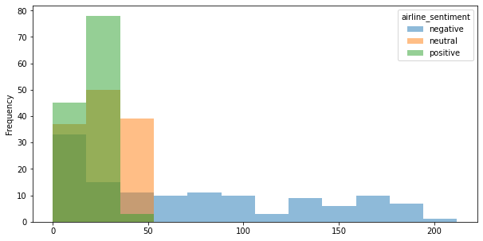

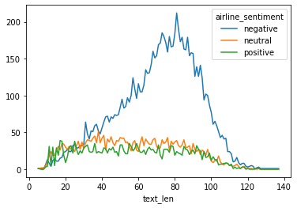

```python
#Observe the Tweets length for all the sentiment type
df_t["text_len"] = df_t.text_string.map(lambda x: len(x))
pd.crosstab(df_t['text_len'],df_t['airline_sentiment']).plot(kind='hist',figsize=(10,5),bins=12, alpha=0.5)
pd.crosstab(df_t['text_len'],df_t['airline_sentiment']).plot.line()
```

**OBSERVATIONS:**

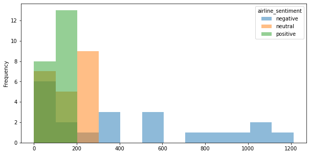

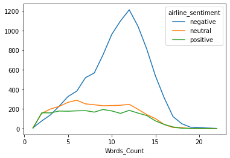

```python
df_t["Words_Count"] = df_t.text_string.str.split().map(lambda x: len(x))
pd.crosstab(df_t['Words_Count'],df_t['airline_sentiment']).plot(kind='hist',figsize=(10,5),bins=12, alpha=0.5)
pd.crosstab(df_t['Words_Count'],df_t['airline_sentiment']).plot.line()
```

# **3. Vectorization: (10 Marks)**

- **a. Use CountVectorizer.**
- **b. Use TfidfVectorizer.**

**Use CountVectorizer**

```python
# Count Vectorization (Convert text data to numbers).
from sklearn.feature_extraction.text import CountVectorizer
cv_vectorizer = CountVectorizer(max_features=5000)                # Keep only 5000 features as number of features will increase the processing time.
cv_data_features = cv_vectorizer.fit_transform(df_t['text_string'])
cv_data_features = cv_data_features.toarray()
```

```python
cv_data_features.shape
```

```
(14640, 5000)
```

```python
# Visualize the Count Vectorizer words
cv = pd.DataFrame(cv_data_features, columns = cv_vectorizer.get_feature_names())
cv
```

|  | aa | aacom | aadfw | aadv | aadvantage | aafail | aal | aano | aarp | abandon | abc | abcnetwork | abilities | ability | able | aboard | abq | abroad | absolute | absolutely | absurd | abt | abuse | abysmal | ac | accept | acceptable | access | accident | … |
| --- | --- | --- | --- | --- | --- | --- | --- | --- | --- | --- | --- | --- | --- | --- | --- | --- | --- | --- | --- | --- | --- | --- | --- | --- | --- | --- | --- | --- | --- | --- |
| 0 | 0 | 0 | 0 | 0 | 0 | 0 | 0 | 0 | 0 | 0 | 0 | 0 | 0 | 0 | 0 | 0 | 0 | 0 | 0 | 0 | 0 | 0 | 0 | 0 | 0 | 0 | 0 | 0 | 0 | … |
| 1 | 0 | 0 | 0 | 0 | 0 | 0 | 0 | 0 | 0 | 0 | 0 | 0 | 0 | 0 | 0 | 0 | 0 | 0 | 0 | 0 | 0 | 0 | 0 | 0 | 0 | 0 | 0 | 0 | 0 | … |
| 2 | 0 | 0 | 0 | 0 | 0 | 0 | 0 | 0 | 0 | 0 | 0 | 0 | 0 | 0 | 0 | 0 | 0 | 0 | 0 | 0 | 0 | 0 | 0 | 0 | 0 | 0 | 0 | 0 | 0 | … |
| 3 | 0 | 0 | 0 | 0 | 0 | 0 | 0 | 0 | 0 | 0 | 0 | 0 | 0 | 0 | 0 | 0 | 0 | 0 | 0 | 0 | 0 | 0 | 0 | 0 | 0 | 0 | 0 | 0 | 0 | … |
| 4 | 0 | 0 | 0 | 0 | 0 | 0 | 0 | 0 | 0 | 0 | 0 | 0 | 0 | 0 | 0 | 0 | 0 | 0 | 0 | 0 | 0 | 0 | 0 | 0 | 0 | 0 | 0 | 0 | 0 | … |
| ... | ... | ... | ... | ... | ... | ... | ... | ... | ... | ... | ... | ... | ... | ... | ... | ... | ... | ... | ... | ... | ... | ... | ... | ... | ... | ... | ... | ... | ... | … |
| 14635 | 0 | 0 | 0 | 0 | 0 | 0 | 0 | 0 | 0 | 0 | 0 | 0 | 0 | 0 | 0 | 0 | 0 | 0 | 0 | 0 | 0 | 0 | 0 | 0 | 0 | 0 | 0 | 0 | 0 | … |
| 14636 | 0 | 0 | 0 | 0 | 0 | 0 | 0 | 0 | 0 | 0 | 0 | 0 | 0 | 0 | 0 | 0 | 0 | 0 | 0 | 0 | 0 | 0 | 0 | 0 | 0 | 0 | 0 | 0 | 0 | … |
| 14637 | 0 | 0 | 0 | 0 | 0 | 0 | 0 | 0 | 0 | 0 | 0 | 0 | 0 | 0 | 0 | 0 | 0 | 0 | 0 | 0 | 0 | 0 | 0 | 0 | 0 | 0 | 0 | 0 | 0 | … |
| 14638 | 0 | 0 | 0 | 0 | 0 | 0 | 0 | 0 | 0 | 0 | 0 | 0 | 0 | 0 | 0 | 0 | 0 | 0 | 0 | 0 | 0 | 0 | 0 | 0 | 0 | 0 | 0 | 0 | 0 | … |
| 14639 | 0 | 0 | 0 | 0 | 0 | 0 | 0 | 0 | 0 | 0 | 0 | 0 | 0 | 0 | 0 | 0 | 0 | 0 | 0 | 0 | 0 | 0 | 0 | 0 | 0 | 0 | 0 | 0 | 0 | … |

14640 rows × 5000 columns

**TF-IDF**</br> In the bag of words approach, each word has the same weight. The idea behind the TF-IDF approach is that the words that occur less in all the documents and more in individual document contribute more towards classification.

TF-IDF is a combination of two terms. Term frequency and Inverse Document frequency. They can be calculated as:

TF = (Frequency of a word in the document)/(Total words in the document) IDF * Log((Total number of docs)/(Number of docs containing the word))

```python
# Using TfidfVectorizer to convert text data to numbers.
from sklearn.feature_extraction.text import TfidfVectorizer
tfidf_vectorizer = TfidfVectorizer(max_features=5000, min_df=8, max_df=0.8)
tfidf_data_features = tfidf_vectorizer.fit_transform(df_t['text_string'])
tfidf_data_features = tfidf_data_features.toarray()
tfidf_data_features.shape
```

```
(14640, 1688)
```

In the code above, we define that the max_features should be 5000, which means that it only uses the 5000 most frequently occurring words to create a bag of words feature vector. Words that occur less frequently are not very useful for classification.

```python
#Visualize the features after tfidf
feature_names = tfidf_vectorizer.get_feature_names()
df = pd.DataFrame(tfidf_data_features.T, index=feature_names).T
df
```

|  | aa | aadvantage | abc | able | abq | absolute | absolutely | absurd | ac | accept | acceptable | access | accommodate | accommodations | accord | account | acct | accurate | across | act | action | actual | actually | add | additional | address | admirals | advance | advantage | … |
| --- | --- | --- | --- | --- | --- | --- | --- | --- | --- | --- | --- | --- | --- | --- | --- | --- | --- | --- | --- | --- | --- | --- | --- | --- | --- | --- | --- | --- | --- | --- |
| 0 | 0.0 | 0.0 | 0.0 | 0.0 | 0.0 | 0.0 | 0.0 | 0.0 | 0.0 | 0.0 | 0.0 | 0.0 | 0.0 | 0.0 | 0.0 | 0.0 | 0.0 | 0.0 | 0.0 | 0.0 | 0.0 | 0.0 | 0.0 | 0.000000 | 0.0 | 0.0 | 0.0 | 0.0 | 0.0 | … |
| 1 | 0.0 | 0.0 | 0.0 | 0.0 | 0.0 | 0.0 | 0.0 | 0.0 | 0.0 | 0.0 | 0.0 | 0.0 | 0.0 | 0.0 | 0.0 | 0.0 | 0.0 | 0.0 | 0.0 | 0.0 | 0.0 | 0.0 | 0.0 | 0.524539 | 0.0 | 0.0 | 0.0 | 0.0 | 0.0 | … |
| 2 | 0.0 | 0.0 | 0.0 | 0.0 | 0.0 | 0.0 | 0.0 | 0.0 | 0.0 | 0.0 | 0.0 | 0.0 | 0.0 | 0.0 | 0.0 | 0.0 | 0.0 | 0.0 | 0.0 | 0.0 | 0.0 | 0.0 | 0.0 | 0.000000 | 0.0 | 0.0 | 0.0 | 0.0 | 0.0 | … |
| 3 | 0.0 | 0.0 | 0.0 | 0.0 | 0.0 | 0.0 | 0.0 | 0.0 | 0.0 | 0.0 | 0.0 | 0.0 | 0.0 | 0.0 | 0.0 | 0.0 | 0.0 | 0.0 | 0.0 | 0.0 | 0.0 | 0.0 | 0.0 | 0.000000 | 0.0 | 0.0 | 0.0 | 0.0 | 0.0 | … |
| 4 | 0.0 | 0.0 | 0.0 | 0.0 | 0.0 | 0.0 | 0.0 | 0.0 | 0.0 | 0.0 | 0.0 | 0.0 | 0.0 | 0.0 | 0.0 | 0.0 | 0.0 | 0.0 | 0.0 | 0.0 | 0.0 | 0.0 | 0.0 | 0.000000 | 0.0 | 0.0 | 0.0 | 0.0 | 0.0 | … |
| ... | ... | ... | ... | ... | ... | ... | ... | ... | ... | ... | ... | ... | ... | ... | ... | ... | ... | ... | ... | ... | ... | ... | ... | ... | ... | ... | ... | ... | ... | … |
| 14635 | 0.0 | 0.0 | 0.0 | 0.0 | 0.0 | 0.0 | 0.0 | 0.0 | 0.0 | 0.0 | 0.0 | 0.0 | 0.0 | 0.0 | 0.0 | 0.0 | 0.0 | 0.0 | 0.0 | 0.0 | 0.0 | 0.0 | 0.0 | 0.000000 | 0.0 | 0.0 | 0.0 | 0.0 | 0.0 | … |
| 14636 | 0.0 | 0.0 | 0.0 | 0.0 | 0.0 | 0.0 | 0.0 | 0.0 | 0.0 | 0.0 | 0.0 | 0.0 | 0.0 | 0.0 | 0.0 | 0.0 | 0.0 | 0.0 | 0.0 | 0.0 | 0.0 | 0.0 | 0.0 | 0.000000 | 0.0 | 0.0 | 0.0 | 0.0 | 0.0 | … |
| 14637 | 0.0 | 0.0 | 0.0 | 0.0 | 0.0 | 0.0 | 0.0 | 0.0 | 0.0 | 0.0 | 0.0 | 0.0 | 0.0 | 0.0 | 0.0 | 0.0 | 0.0 | 0.0 | 0.0 | 0.0 | 0.0 | 0.0 | 0.0 | 0.000000 | 0.0 | 0.0 | 0.0 | 0.0 | 0.0 | … |
| 14638 | 0.0 | 0.0 | 0.0 | 0.0 | 0.0 | 0.0 | 0.0 | 0.0 | 0.0 | 0.0 | 0.0 | 0.0 | 0.0 | 0.0 | 0.0 | 0.0 | 0.0 | 0.0 | 0.0 | 0.0 | 0.0 | 0.0 | 0.0 | 0.000000 | 0.0 | 0.0 | 0.0 | 0.0 | 0.0 | … |
| 14639 | 0.0 | 0.0 | 0.0 | 0.0 | 0.0 | 0.0 | 0.0 | 0.0 | 0.0 | 0.0 | 0.0 | 0.0 | 0.0 | 0.0 | 0.0 | 0.0 | 0.0 | 0.0 | 0.0 | 0.0 | 0.0 | 0.0 | 0.0 | 0.000000 | 0.0 | 0.0 | 0.0 | 0.0 | 0.0 | … |

14640 rows × 1688 columns

# **5. Fit and evaluate model using both type of vectorization. (6+6 Marks)**

```python
# Labeling - either one-hot or get dummies ( I prefer get dummies so we can visualize the respective seed name on the column)
yy = pd.get_dummies(df_t['airline_sentiment'])
yy.columns
```

```
Index(['negative', 'neutral', 'positive'], dtype='object')
```

```python
# convert to array
y = np.array(yy)
print('y Shape:',y.shape)
```

```
y Shape: (14640, 3)
```

**Use CountVectorizer**

```python
# Split data into training and testing set.
from sklearn.model_selection import train_test_split
X_train, X_test, y_train, y_test = train_test_split(cv_data_features, y, test_size=0.2, random_state=141)
```

```python
print(X_train.shape,X_test.shape,y_train.shape,y_test.shape)
```

```
(11712, 5000) (2928, 5000) (11712, 3) (2928, 3)
```

```python
# Using Random Forest to build model for the classification of reviews.
# Also calculating the cross validation score.
forest = RandomForestClassifier(n_estimators=20, n_jobs=4, random_state=141)
forest = forest.fit(X_train, y_train)
print(forest)
Roc_Auc_Score_CrossValdiation = np.mean(cross_val_score(forest, cv_data_features, y, cv=10,scoring='roc_auc'))
print('Cross Validation Score',Roc_Auc_Score_CrossValdiation)
```

```
RandomForestClassifier(bootstrap=True, ccp_alpha=0.0, class_weight=None,
                       criterion='gini', max_depth=None, max_features='auto',
                       max_leaf_nodes=None, max_samples=None,
                       min_impurity_decrease=0.0, min_impurity_split=None,
                       min_samples_leaf=1, min_samples_split=2,
                       min_weight_fraction_leaf=0.0, n_estimators=20, n_jobs=4,
                       oob_score=False, random_state=141, verbose=0,
                       warm_start=False)
Cross Validation Score 0.8232724338926433
```

```python
# Predict the result for test data using the model built above.
y_predict = forest.predict(X_test)
```

```python
print("Trainig accuracy",forest.score(X_train,y_train))
print()
print("Testing accuracy",forest.score(X_test, y_test))
print()
print("Recall:",recall_score(y_test,y_predict,average='weighted'))
print()
print("Precision:",precision_score(y_test,y_predict,average='weighted'))
print()
print("F1 Score:",f1_score(y_test,y_predict,average='weighted'))
```

```
Trainig accuracy 0.9867657103825137

Testing accuracy 0.6827185792349727

Recall: 0.6827185792349727

Precision: 0.7678540081007742

F1 Score: 0.7131988308214414
```

```python
# Prepare result dataframe
results = pd.DataFrame(columns=['Vectorizer','max_features','min_df','max_df','Model','Train_Accuracy','Test_Accuracy','Recall','Precission','F1_Score','CrossVal_Roc_Auc_Score'])
results
```

|  | Vectorizer | max_features | min_df | max_df | Model | Train_Accuracy | Test_Accuracy | Recall | Precission | F1_Score | CrossVal_Roc_Auc_Score |
| --- | --- | --- | --- | --- | --- | --- | --- | --- | --- | --- | --- |

```python
count=0
idx=count+1
m1 ="Count"
m2 = 5000
m3 = "-"
m4 = "-"
m5 = "Random Forest"
m6 = forest.score(X_train,y_train)
m7 = forest.score(X_test, y_test)
m8 = recall_score(y_test,y_predict,average='weighted')
m9 = precision_score(y_test,y_predict,average='weighted')
m10 = f1_score(y_test,y_predict,average='weighted')
m11 = Roc_Auc_Score_CrossValdiation
results.loc[idx]=[m1,m2,m3,m4,m5,m6,m7,m8,m9,m10,m11]
results
```

|  | Vectorizer | max_features | min_df | max_df | Model | Train_Accuracy | Test_Accuracy | Recall | Precission | F1_Score | CrossVal_Roc_Auc_Score |
| --- | --- | --- | --- | --- | --- | --- | --- | --- | --- | --- | --- |
| 1 | Count | 5000 | - | - | Random Forest | 0.986766 | 0.682719 | 0.682719 | 0.767854 | 0.713199 | 0.823272 |

```
Confusion Matrix
```

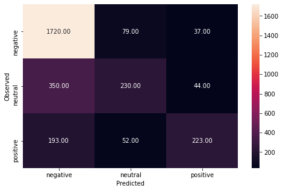

```
None
```

```python
from mlxtend.plotting import plot_confusion_matrix
from sklearn.metrics import confusion_matrix
## function to get confusion matrix in a proper format
plt.figure(figsize=(8,5))
def draw_cm( y_test, y_predict_e ):
    cm = confusion_matrix(  y_test, y_predict_e)
    sns.heatmap(cm, annot=True,  fmt='.2f', xticklabels = yy.columns , yticklabels = yy.columns )
    plt.ylabel('Observed')
    plt.xlabel('Predicted')
    plt.show()

print('Confusion Matrix')
print(draw_cm(y_test.argmax(axis=1),y_predict.argmax(axis=1)))
print()
```

**Use TfidfVectorizer**

```python
# Split data into training and testing set.
from sklearn.model_selection import train_test_split
X_train_t, X_test_t, y_train_t, y_test_t = train_test_split(tfidf_data_features, y, test_size=0.2, random_state=141)
```

```python
print(X_train_t.shape,X_test_t.shape,y_train_t.shape,y_test_t.shape)
```

```
(11712, 1688) (2928, 1688) (11712, 3) (2928, 3)
```

**Tfidf - Random Forest**

```python
# Using Random Forest to build model for the classification of reviews.
# Also calculating the cross validation score.
forest_t = RandomForestClassifier(n_estimators=20, n_jobs=4, random_state=141)
forest_t = forest_t.fit(X_train_t, y_train_t)
print(forest_t)
Roc_Auc_Score_CrossValdiation_t = np.mean(cross_val_score(forest_t, tfidf_data_features, y, cv=10,scoring='roc_auc'))
print('Cross Validation Score:',Roc_Auc_Score_CrossValdiation_t)
```

```
RandomForestClassifier(bootstrap=True, ccp_alpha=0.0, class_weight=None,
                       criterion='gini', max_depth=None, max_features='auto',
                       max_leaf_nodes=None, max_samples=None,
                       min_impurity_decrease=0.0, min_impurity_split=None,
                       min_samples_leaf=1, min_samples_split=2,
                       min_weight_fraction_leaf=0.0, n_estimators=20, n_jobs=4,
                       oob_score=False, random_state=141, verbose=0,
                       warm_start=False)
Cross Validation Score: 0.8243524813596483
```

```python
# Predict the result for test data using the model built above.
y_predict_t = forest_t.predict(X_test_t)
```

```python
print("Trainig accuracy",forest_t.score(X_train_t,y_train_t))
print()
print("Testing accuracy",forest_t.score(X_test_t, y_test_t))
print()
print("Recall:",recall_score(y_test_t,y_predict_t,average='weighted'))
print()
print("Precision:",precision_score(y_test_t,y_predict_t,average='weighted'))
print()
print("F1 Score:",f1_score(y_test_t,y_predict_t,average='weighted'))
```

```
Trainig accuracy 0.9818989071038251

Testing accuracy 0.6915983606557377

Recall: 0.6915983606557377

Precision: 0.7668998717768599

F1 Score: 0.708221181548114
```

```python
idx=idx+1
m1 ="tfidf"
m2 = 5000
m3 = 8
m4 = 0.8
m5 = "Random Forest"
m6 = forest_t.score(X_train_t,y_train_t)
m7 = forest_t.score(X_test_t, y_test_t)
m8 = recall_score(y_test_t,y_predict_t,average='weighted')
m9 = precision_score(y_test_t,y_predict_t,average='weighted')
m10 = f1_score(y_test_t,y_predict_t,average='weighted')
m11 = Roc_Auc_Score_CrossValdiation_t
results.loc[idx]=[m1,m2,m3,m4,m5,m6,m7,m8,m9,m10,m11]
results
```

|  | Vectorizer | max_features | min_df | max_df | Model | Train_Accuracy | Test_Accuracy | Recall | Precission | F1_Score | CrossVal_Roc_Auc_Score |
| --- | --- | --- | --- | --- | --- | --- | --- | --- | --- | --- | --- |
| 1 | Count | 5000 | - | - | Random Forest | 0.986766 | 0.682719 | 0.682719 | 0.767854 | 0.713199 | 0.823272 |
| 2 | tfidf | 5000 | 8 | 0.8 | Random Forest | 0.981899 | 0.691598 | 0.691598 | 0.766900 | 0.708221 | 0.824352 |

```
Confusion Matrix
```

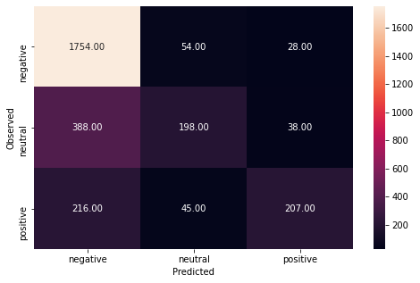

```
None
```

```python
from mlxtend.plotting import plot_confusion_matrix
from sklearn.metrics import confusion_matrix
## function to get confusion matrix in a proper format
import seaborn as sns
plt.figure(figsize=(8,5))
def draw_cm( y_test, y_predict_e ):
    cm = confusion_matrix(  y_test, y_predict_e)
    sns.heatmap(cm, annot=True,  fmt='.2f', xticklabels = yy.columns , yticklabels = yy.columns )
    plt.ylabel('Observed')
    plt.xlabel('Predicted')
    plt.show()

print('Confusion Matrix')
print(draw_cm(y_test_t.argmax(axis=1),y_predict_t.argmax(axis=1)))
print()
```

```python
from sklearn.neighbors import KNeighborsClassifier
Knn_clf = KNeighborsClassifier(n_neighbors = 5) #no of neighbors is hpyer parameter
Knn_clf.fit(X_train_t, y_train_t)
```

```
KNeighborsClassifier(algorithm='auto', leaf_size=30, metric='minkowski',
                     metric_params=None, n_jobs=None, n_neighbors=5, p=2,
                     weights='uniform')
```

```python
import numpy as np
Roc_Auc_Score_CrossValdiation_knn = np.mean(cross_val_score(Knn_clf, tfidf_data_features, y, cv=10,scoring='roc_auc'))
print('Cross Validation Score:',Roc_Auc_Score_CrossValdiation_knn)
```

```
Cross Validation Score: 0.773637339806006
```

```python
# Predict the result for test data using the model built above.
y_predict_t = Knn_clf.predict(X_test_t)
```

```python
print("Trainig accuracy",Knn_clf.score(X_train_t,y_train_t))
print()
print("Testing accuracy",Knn_clf.score(X_test_t, y_test_t))
print()
print("Recall:",recall_score(y_test_t,y_predict_t,average='weighted'))
print()
print("Precision:",precision_score(y_test_t,y_predict_t,average='weighted'))
print()
print("F1 Score:",f1_score(y_test_t,y_predict_t,average='weighted'))
```

```
Trainig accuracy 0.7518784153005464

Testing accuracy 0.6260245901639344

Recall: 0.6260245901639344

Precision: 0.7152355765235291

F1 Score: 0.6673761911213305
```

```python
idx=idx+1
m1 ="tfidf"
m2 = 5000
m3 = 8
m4 = 0.8
m5 = "KNN"
m6 = Knn_clf.score(X_train_t,y_train_t)
m7 = Knn_clf.score(X_test_t, y_test_t)
m8 = recall_score(y_test_t,y_predict_t,average='weighted')
m9 = precision_score(y_test_t,y_predict_t,average='weighted')
m10 = f1_score(y_test_t,y_predict_t,average='weighted')
m11 = Roc_Auc_Score_CrossValdiation_knn
results.loc[idx]=[m1,m2,m3,m4,m5,m6,m7,m8,m9,m10,m11]
results
```

|  | Vectorizer | max_features | min_df | max_df | Model | Train_Accuracy | Test_Accuracy | Recall | Precission | F1_Score | CrossVal_Roc_Auc_Score |
| --- | --- | --- | --- | --- | --- | --- | --- | --- | --- | --- | --- |
| 1 | Count | 5000 | - | - | Random Forest | 0.986766 | 0.682719 | 0.682719 | 0.767854 | 0.713199 | 0.823272 |
| 2 | tfidf | 5000 | 8 | 0.8 | Random Forest | 0.981899 | 0.691598 | 0.691598 | 0.766900 | 0.708221 | 0.824352 |
| 3 | tfidf | 5000 | 8 | 0.8 | KNN | 0.751878 | 0.626025 | 0.626025 | 0.715236 | 0.667376 | 0.773637 |

```
Confusion Matrix
```

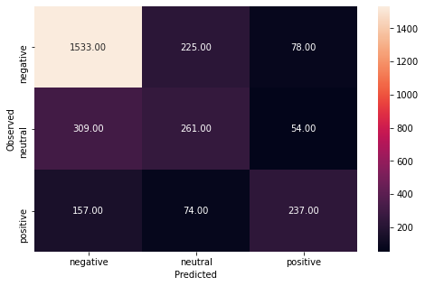

```
None
```

```python
from mlxtend.plotting import plot_confusion_matrix
from sklearn.metrics import confusion_matrix
## function to get confusion matrix in a proper format
import seaborn as sns
plt.figure(figsize=(8,5))
def draw_cm( y_test, y_predict_e ):
    cm = confusion_matrix(  y_test, y_predict_e)
    sns.heatmap(cm, annot=True,  fmt='.2f', xticklabels = yy.columns , yticklabels = yy.columns )
    plt.ylabel('Observed')
    plt.xlabel('Predicted')
    plt.show()

print('Confusion Matrix')
print(draw_cm(y_test_t.argmax(axis=1),y_predict_t.argmax(axis=1)))
print()
```

**Tfidf - Decission Tree**

```python
from sklearn.tree import DecisionTreeClassifier
DT= DecisionTreeClassifier(criterion="gini")
DT.fit(X_train_t, y_train_t)
```

```
DecisionTreeClassifier(ccp_alpha=0.0, class_weight=None, criterion='gini',
                       max_depth=None, max_features=None, max_leaf_nodes=None,
                       min_impurity_decrease=0.0, min_impurity_split=None,
                       min_samples_leaf=1, min_samples_split=2,
                       min_weight_fraction_leaf=0.0, presort='deprecated',
                       random_state=None, splitter='best')
```

```python
import numpy as np
Roc_Auc_Score_CrossValdiation_dt = np.mean(cross_val_score(DT, tfidf_data_features, y, cv=10,scoring='roc_auc'))
print('Cross Validation Score:',Roc_Auc_Score_CrossValdiation_dt)
```

```
Cross Validation Score: 0.6656141020796407
```

```python
# Predict the result for test data using the model built above.
y_predict_t = DT.predict(X_test_t)
```

```python
print("Trainig accuracy",DT.score(X_train_t,y_train_t))
print()
print("Testing accuracy",DT.score(X_test_t, y_test_t))
print()
print("Recall:",recall_score(y_test_t,y_predict_t,average='weighted'))
print()
print("Precision:",precision_score(y_test_t,y_predict_t,average='weighted'))
print()
print("F1 Score:",f1_score(y_test_t,y_predict_t,average='weighted'))
```

```
Trainig accuracy 0.9890710382513661

Testing accuracy 0.6693989071038251

Recall: 0.6693989071038251

Precision: 0.6628441875126743

F1 Score: 0.6654092927429542
```

```python
idx=idx+1
m1 ="tfidf"
m2 = 5000
m3 = 8
m4 = 0.8
m5 = "DT"
m6 = DT.score(X_train_t,y_train_t)
m7 = DT.score(X_test_t, y_test_t)
m8 = recall_score(y_test_t,y_predict_t,average='weighted')
m9 = precision_score(y_test_t,y_predict_t,average='weighted')
m10 = f1_score(y_test_t,y_predict_t,average='weighted')
m11 = Roc_Auc_Score_CrossValdiation_knn
results.loc[idx]=[m1,m2,m3,m4,m5,m6,m7,m8,m9,m10,m11]
results
```

[output not shown]

```
Confusion Matrix
```

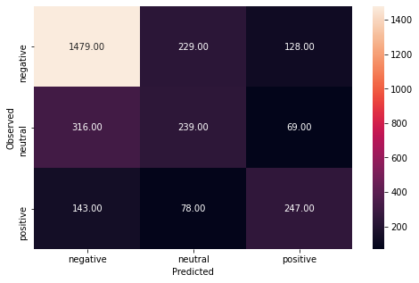

```
None
```

```python
from mlxtend.plotting import plot_confusion_matrix
from sklearn.metrics import confusion_matrix
## function to get confusion matrix in a proper format
import seaborn as sns
plt.figure(figsize=(8,5))
def draw_cm( y_test, y_predict_e ):
    cm = confusion_matrix(  y_test, y_predict_e)
    sns.heatmap(cm, annot=True,  fmt='.2f', xticklabels = yy.columns , yticklabels = yy.columns )
    plt.ylabel('Observed')
    plt.xlabel('Predicted')
    plt.show()

print('Confusion Matrix')
print(draw_cm(y_test_t.argmax(axis=1),y_predict_t.argmax(axis=1)))
print()
```

# **6.Summarize your understanding of the application of Various Pre-processing and Vectorization and performance of your model on this dataset. (8 Marks)**

**Twitter US Airline Dataset contains Tweets for multiple airlines which is shown graphically in the above section. After reviewing the data most of the negitive feedback is in cusotomer service.**

**Observing the Target feature "airlines_sentiment", it shows that approximately 62% of the data set is negative sentment it means the data set is unbalanced for the model preparation.**

**To build the supervised machine learning model, The Tweets text need to do preprocessing. This includes multiple steps involved**

- Html tag removal : Text data is extracted from multiple sources where html tags are included which need to clean for this we are using BeautifulSoup
- Tokenization : This seperate all the words including punctuations like a tokens
- Remove the numbers : Using RE numbers also removed which are not a meaningful insight to review the sentiments
- Removal of Special Characters and Punctuations : Similarly Special Characters using ASCII numbers and Puctuations are removed
- Conversion to lowercase : Converting all the characters to lower case will reduce the complexity in the case sensitivity information hence the performance of the model is increased
- Lemmatize or stemming : Compare to Stemming, Lemmatization will give better foramtion of text where tokens are validated with the english dictionary.

**Once the Data Preprocessing is completed the text will contain the unique words that represents the actual sentiment of the model to predict. Now the next step is creating bag of words vectorization. This can be achieved by different ways. some of them are Count vectorization and Tfidf Vectorization. We can also use bigrams, trigrams ... ngrams to prepare more bag of words to represent the more meaningful sentiments. In this notebook I didnt consider ngrams but Both Count vectorizaiton and Tfidf vectorizationsa are illlustrated with mutliple supervised classificaiton models to evaolutate the model performance.**

**TF-IDF**</br> In the bag of words approach, each word has the same weight. The idea behind the TF-IDF approach is that the words that occur less in all the documents and more in individual document contribute more towards classification.

TF-IDF is a combination of two terms. Term frequency and Inverse Document frequency. They can be calculated as:

TF = (Frequency of a word in the document)/(Total words in the document) IDF * Log((Total number of docs)/(Number of docs containing the word))**

- **The pre-precessed data is converted to numbers, so that we can feed the data in the model**

```python
results
```

[output not shown]

**Multiple Algorithems with Cross validation process evoluted the model performance. The better accuracy is achieved by Tfidf vectorization and with Random Forest model. Cross validation score for Roc_auc for this model is 82.43%. This can more fine tuned with hyperparameters tuning further. Recall is 69.15% which is also resonalbly good score with the F1score is 71%. Another enhancement can be using ngrams which will increase the accuracy by selecting proper word sets to represent the right sentiment analysis.**